# Pregunta 1: [20 puntos] Dada la siguiente Tabla de Testing de un Scoring de Crédito:

```python
#Variables predictoras
X = datos.iloc[:,:9]
#se escalan
X = pd.DataFrame(StandardScaler().fit_transform(X), columns= X.columns)
X.head()
```

[output not shown]

```python
#variable a predecir
y = datos.iloc[:,9].ravel()
y
```

```python
# Train-test
X_train, X_test, y_train, y_test = train_test_split(X, y, train_size=0.75, random_state=0)
```

```python
instancia_knn = KNeighborsClassifier(n_neighbors=3,)
```

```python
instancia_knn.fit(X_train.values,y_train)
```

```
KNeighborsClassifier(n_neighbors=3)
```

```python
# indices de calidad

prediccion = instancia_knn.predict(X_test.values)

labels = ["Si","No"]
MC = confusion_matrix(y_test, prediccion,labels = labels)

indices = indices_general(MC, labels)
for k in indices:
    print("\n%s:\n%s"%(k,str(indices[k])))
```

```
Matriz de Confusión:
[[ 92 102]
 [ 79 230]]

Precisión Global:
0.6401590457256461

Error Global:
0.3598409542743539

Precisión por categoría:
         Si        No
0  0.474227  0.744337
```

## 4. Genere un Modelo Predictivo usando K vecinos más cercanos para cada uno de los siguientes núcleos `ball_tree`, `kd_tree` y `brute` ¿Cuál produce los mejores resultados en el sentido de que predice mejor?

- ### Brute

```python
instancia_knn = KNeighborsClassifier(n_neighbors=3,algorithm='brute',p=3)
instancia_knn.fit(X_train.values,y_train)
prediccion = instancia_knn.predict(X_test.values)

labels = ["Si","No"]
MC = confusion_matrix(y_test, prediccion, labels = labels)

indices = indices_general(MC,labels)
for k in indices:
    print("\n%s:\n%s"%(k,str(indices[k])))
```

```
Matriz de Confusión:
[[ 89 105]
 [ 74 235]]

Precisión Global:
0.6441351888667992

Error Global:
0.3558648111332008

Precisión por categoría:
         Si        No
0  0.458763  0.760518
```

- ### ball_tree

```python
instancia_knn = KNeighborsClassifier(n_neighbors=3,algorithm='ball_tree',p=3)
instancia_knn.fit(X_train.values,y_train)
prediccion = instancia_knn.predict(X_test.values)

labels = ["Si","No"]
MC = confusion_matrix(y_test, prediccion, labels = labels)

indices = indices_general(MC,labels)
for k in indices:
    print("\n%s:\n%s"%(k,str(indices[k])))
```

```
Matriz de Confusión:
[[ 89 105]
 [ 74 235]]

Precisión Global:
0.6441351888667992

Error Global:
0.3558648111332008

Precisión por categoría:
         Si        No
0  0.458763  0.760518
```

- ### kd_tree

```python
instancia_knn = KNeighborsClassifier(n_neighbors=3,algorithm='kd_tree',p=3)
instancia_knn.fit(X_train.values,y_train)
prediccion = instancia_knn.predict(X_test.values)

labels = ["Si","No"]
MC = confusion_matrix(y_test, prediccion, labels = labels)

indices = indices_general(MC,labels)
for k in indices:
    print("\n%s:\n%s"%(k,str(indices[k])))
```

```
Matriz de Confusión:
[[ 89 105]
 [ 74 235]]

Precisión Global:
0.6441351888667992

Error Global:
0.3558648111332008

Precisión por categoría:
         Si        No
0  0.458763  0.760518
```

Los tres producen los mismos resultados

# Pregunta 4: [25 puntos] Este conjunto de datos es originalmente del Instituto Nacional de Diabetes y Enfermedades Digestivas y Renales. El objetivo del conjunto de datos es predecir de forma diagnóstica si un paciente tiene diabetes o no, basándose en determinadas medidas de diagnóstico incluidas en el conjunto de datos..

# 1. Cargue en Python la tabla de datos `diabetes_V2.csv`.

```python
datos = pd.read_csv('../datos/diabetes_V2.csv',delimiter=',',decimal=".",index_col=0)
print(datos.info(), "\n")
print(datos.shape)
datos
```

```
<class 'pandas.core.frame.DataFrame'>
Int64Index: 390 entries, 1 to 390
Data columns (total 15 columns):
 #   Column         Non-Null Count  Dtype
---  ------         --------------  -----
 0   colesterol     390 non-null    int64
 1   glucosa        390 non-null    int64
 2   hdl_chol       390 non-null    int64
 3   prop_col_hdl   390 non-null    float64
 4   edad           390 non-null    int64
 5   genero         390 non-null    object
 6   altura         390 non-null    int64
 7   peso           390 non-null    int64
 8   IMC            390 non-null    float64
 9   ps_sistolica   390 non-null    int64
 10  ps_diastolica  390 non-null    int64
 11  cintura        390 non-null    int64
 12  caderas        390 non-null    int64
 13  prop_cin_cad   390 non-null    float64
 14  diabetes       390 non-null    object
dtypes: float64(3), int64(10), object(2)
memory usage: 48.8+ KB
None

(390, 15)
```

|  | colesterol | glucosa | hdl_chol | prop_col_hdl | edad | genero | altura | peso | IMC | ps_sistolica | ps_diastolica | cintura | caderas | prop_cin_cad | diabetes |
| --- | --- | --- | --- | --- | --- | --- | --- | --- | --- | --- | --- | --- | --- | --- | --- |
| 1 | 193 | 77 | 49 | 3.9 | 19 | female | 61 | 119 | 22.5 | 118 | 70 | 32 | 38 | 0.84 | No diabetes |
| 2 | 146 | 79 | 41 | 3.6 | 19 | female | 60 | 135 | 26.4 | 108 | 58 | 33 | 40 | 0.83 | No diabetes |
| 3 | 217 | 75 | 54 | 4.0 | 20 | female | 67 | 187 | 29.3 | 110 | 72 | 40 | 45 | 0.89 | No diabetes |
| 4 | 226 | 97 | 70 | 3.2 | 20 | female | 64 | 114 | 19.6 | 122 | 64 | 31 | 39 | 0.79 | No diabetes |
| 5 | 164 | 91 | 67 | 2.4 | 20 | female | 70 | 141 | 20.2 | 122 | 86 | 32 | 39 | 0.82 | No diabetes |
| ... | ... | ... | ... | ... | ... | ... | ... | ... | ... | ... | ... | ... | ... | ... | ... |
| 386 | 227 | 105 | 44 | 5.2 | 83 | female | 59 | 125 | 25.2 | 150 | 90 | 35 | 40 | 0.88 | No diabetes |
| 387 | 226 | 279 | 52 | 4.3 | 84 | female | 60 | 192 | 37.5 | 144 | 88 | 41 | 48 | 0.85 | Diabetes |
| 388 | 301 | 90 | 118 | 2.6 | 89 | female | 61 | 115 | 21.7 | 218 | 90 | 31 | 41 | 0.76 | No diabetes |
| 389 | 232 | 184 | 114 | 2.0 | 91 | female | 61 | 127 | 24.0 | 170 | 82 | 35 | 38 | 0.92 | Diabetes |
| 390 | 165 | 94 | 69 | 2.4 | 92 | female | 62 | 217 | 39.7 | 160 | 82 | 51 | 51 | 1.00 | No diabetes |

390 rows × 15 columns

## 2. Realice un análisis exploratorio (estadísticas básicas) que incluya: el resumen numérico (media, desviación estándar, etc.), la correlación entre las variables, el poder predictivo de las variables predictoras. Interprete los resultados.

```python
# Convierte las variables a categórica
datos['genero'] = datos['genero'].astype('category')
datos['diabetes'] = datos['diabetes'].astype('category')
```

```python
datos.select_dtypes(['category'])
```

|  | genero | diabetes |
| --- | --- | --- |
| 1 | female | No diabetes |
| 2 | female | No diabetes |
| 3 | female | No diabetes |
| 4 | female | No diabetes |
| 5 | female | No diabetes |
| ... | ... | ... |
| 386 | female | No diabetes |
| 387 | female | Diabetes |
| 388 | female | No diabetes |
| 389 | female | Diabetes |
| 390 | female | No diabetes |

390 rows × 2 columns

- ### Analisis Exploratorio

```
================dimensión===============
(390, 15)
================Percentiles===============
      colesterol  glucosa  hdl_chol  prop_col_hdl   edad  altura   peso  \
0.00        78.0    48.00      12.0           1.5  19.00    52.0   99.0
0.33       186.0    83.00      41.0           3.6  37.37    64.0  159.0
0.50       203.0    90.00      46.0           4.2  44.50    66.0  173.0
0.75       229.0   107.75      59.0           5.4  60.00    69.0  200.0
1.00       443.0   385.00     120.0          19.3  92.00    76.0  325.0

         IMC  ps_sistolica  ps_diastolica  cintura  caderas  prop_cin_cad
0.00  15.200          90.0           48.0     26.0     30.0          0.68
0.33  25.337         126.0           78.0     35.0     40.0          0.85
0.50  27.800         136.0           82.0     37.0     42.0          0.88
0.75  32.275         148.0           90.0     41.0     46.0          0.93
1.00  55.800         250.0          124.0     56.0     64.0          1.14
================Media===============
colesterol       207.230769
glucosa          107.338462
hdl_chol          50.266667
prop_col_hdl       4.524615
edad              46.774359
altura            65.951282
peso             177.407692
IMC               28.775641
ps_sistolica     137.133333
ps_diastolica     83.289744
cintura           37.869231
caderas           42.992308
prop_cin_cad       0.881385
dtype: float64
================Desviación Estándar===============
colesterol       44.608704
glucosa          53.729172
hdl_chol         17.256902
prop_col_hdl      1.734406
edad             16.414826
altura            3.913839
peso             40.355986
IMC               6.592447
```

[output cut: 36 more lines]

```
================Mínimos===============
colesterol       78.00
glucosa          48.00
hdl_chol         12.00
prop_col_hdl      1.50
edad             19.00
altura           52.00
peso             99.00
IMC              15.20
ps_sistolica     90.00
ps_diastolica    48.00
cintura          26.00
caderas          30.00
prop_cin_cad      0.68
dtype: float64
```

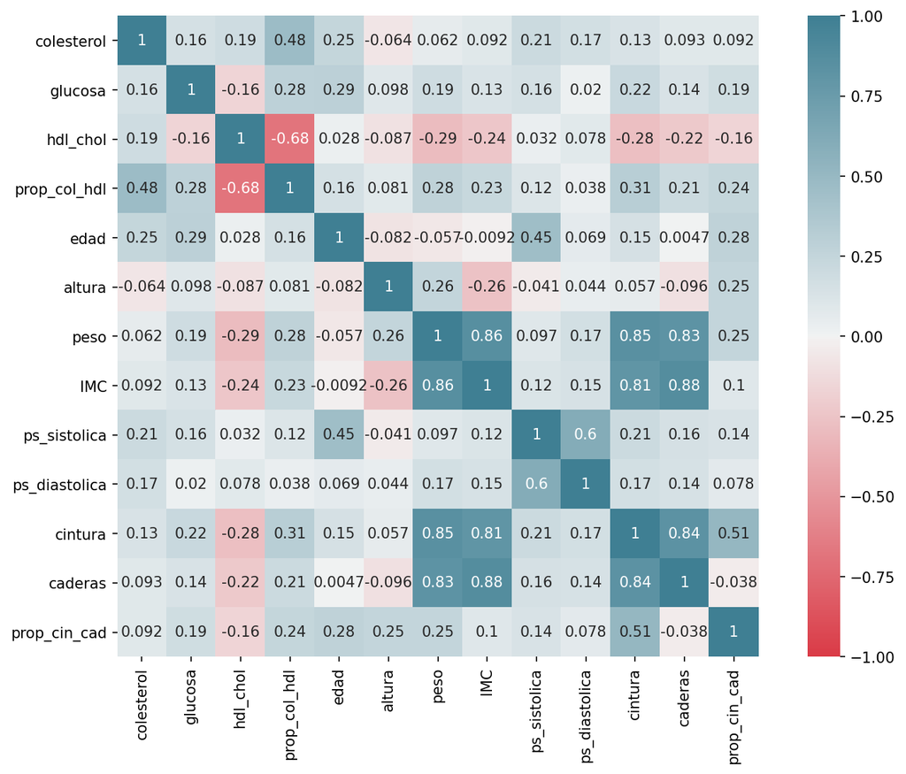

```python
dim = datos.shape
percentiles = datos.quantile(np.array([0,.33,.50,.75,1]))
media= datos.mean(numeric_only=True)
desviacion_estandar = datos.std(numeric_only=True, ddof = 0)
mediana = datos.median(numeric_only=True)
maximos = datos.max(numeric_only=True)
minimos = datos.min(numeric_only=True)



print("================dimensión===============")
print(dim)
print("================Percentiles===============")
print(percentiles)
print("================Media===============")
print(media)
print("================Desviación Estándar===============")
print(desviacion_estandar)
print("================Mediana===============")
print(mediana)
print("================Máximos===============")
print(maximos)
print("================Mínimos===============")
print(minimos)

corr = datos.corr()
fig, ax = plt.subplots(figsize=(12, 8), dpi = 150)

paleta = sns.diverging_palette(220, 10,as_cmap=True).reversed()

sns.heatmap(corr, vmin= -1, vmax=1, cmap= paleta,
            square=True, annot=True, ax=ax)
```

- ### Poder Predictivo

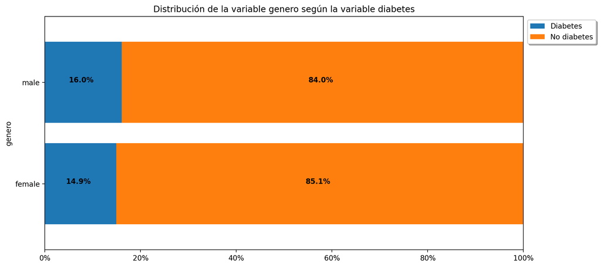

[figure not shown]

```python
for i in range(2):
    col = datos.select_dtypes(['category']).columns[i]
    poder_predictivo_categorica(datos,col,"diabetes")
```

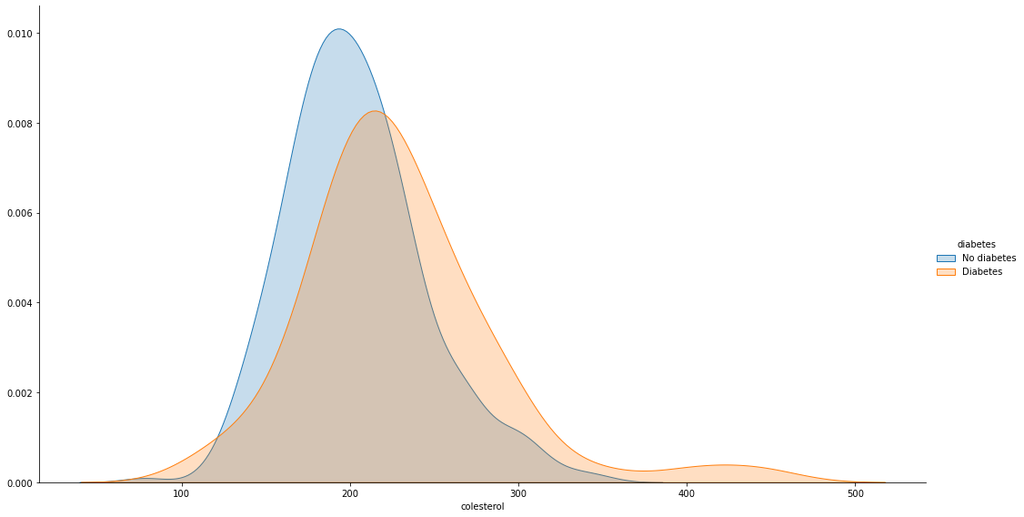

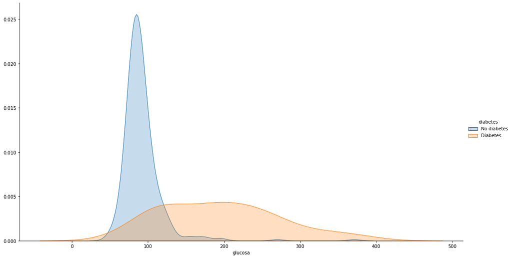

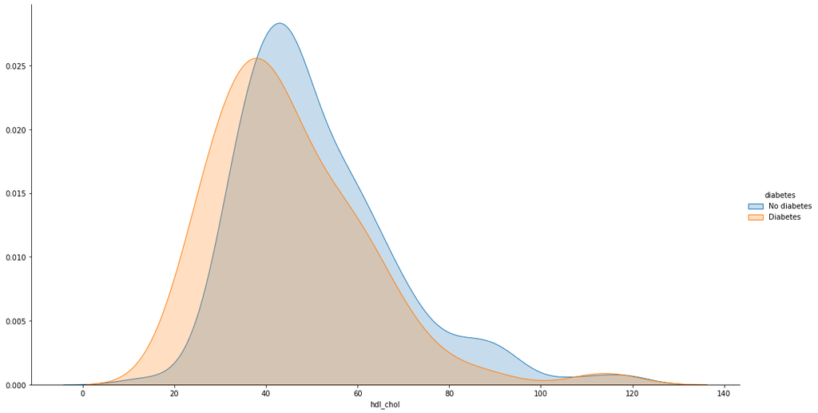

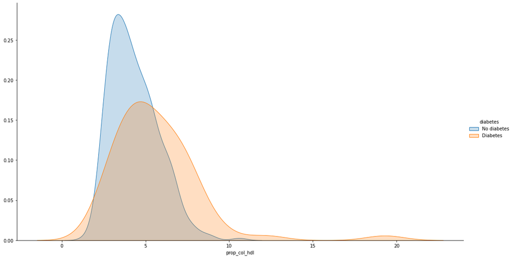

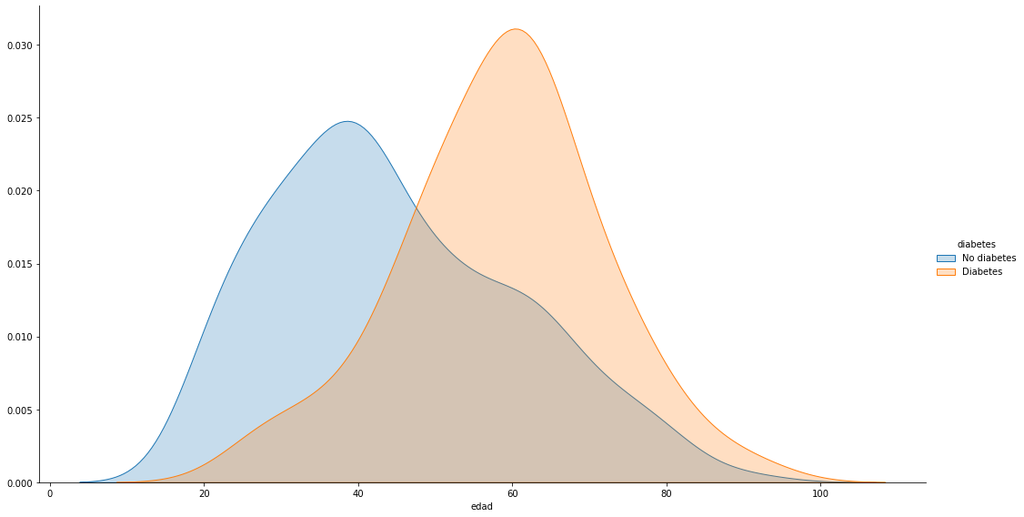

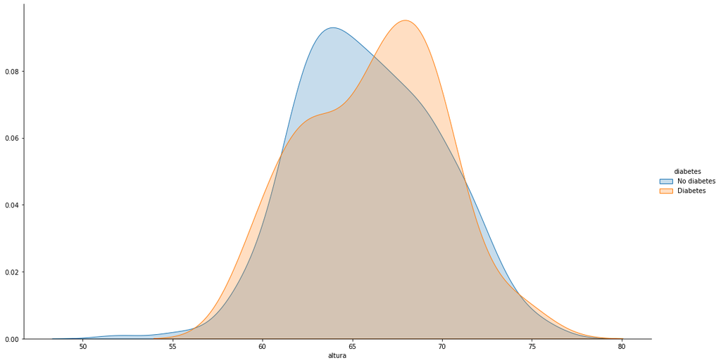

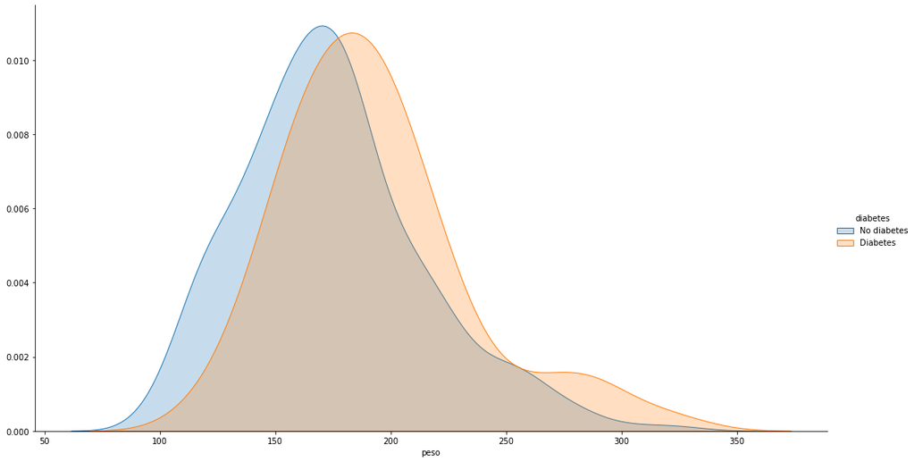

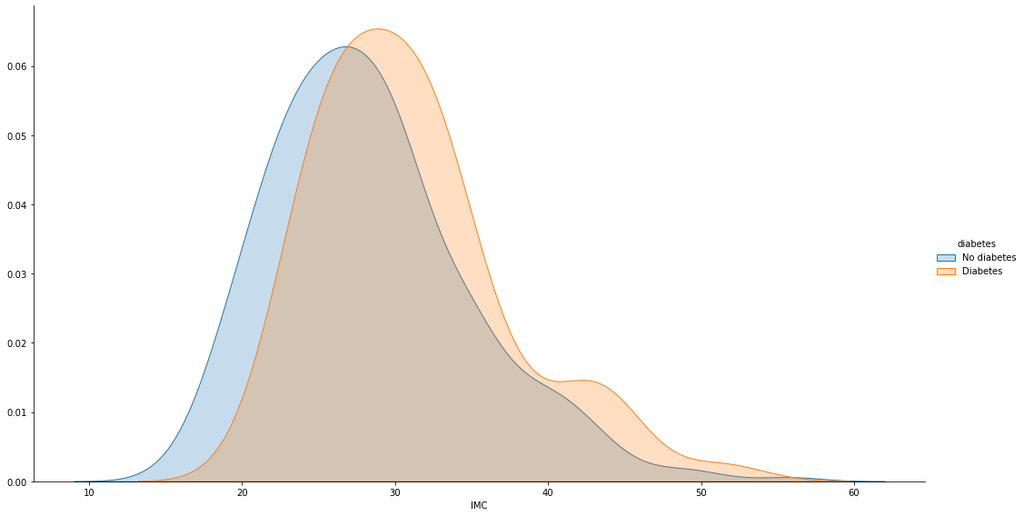

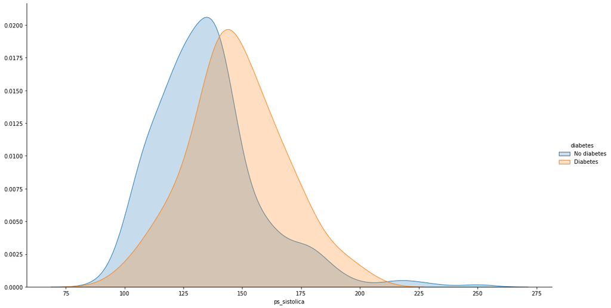

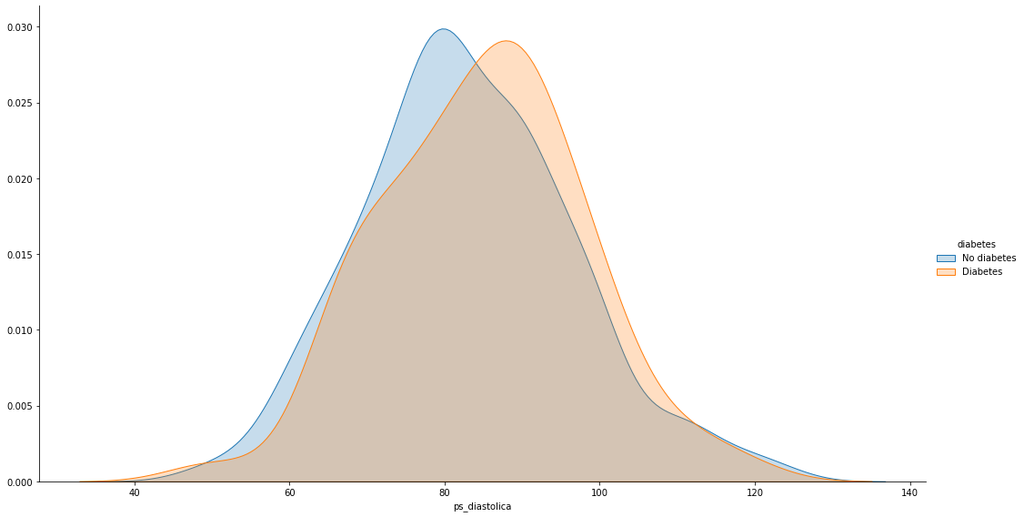

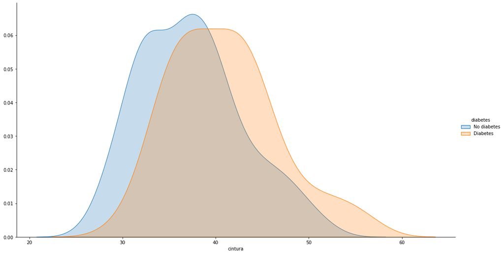

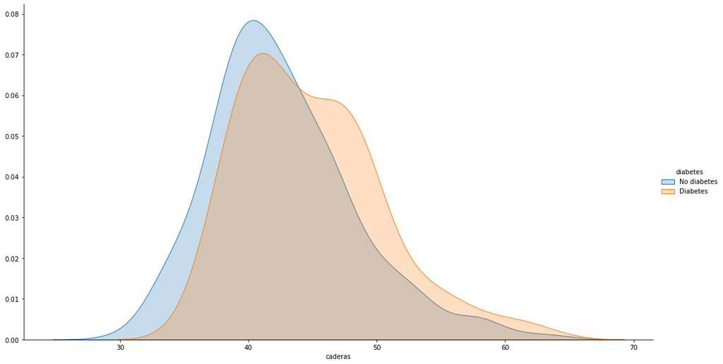

[1 more figures not shown]

```python
datos_num = datos._get_numeric_data()

for i in range(datos_num.shape[1]):
    col = datos_num.columns[i]
    poder_predictivo_numerica(datos,col,"diabetes")
```